# Announcements

Make sure to sign in on the [google form](https://forms.gle/BS4XXnzdR53ZhxDS9).

# Stonks

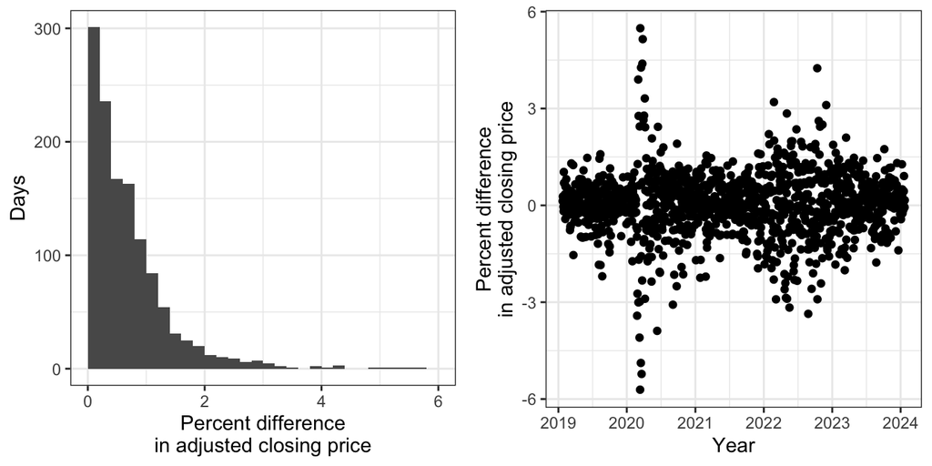

In this section, we will be modeling the day-to-day percent differences in the adjusted closing price of the S&P 500 as $Y_1,...,Y_n\sim\textrm{Expo}(\lambda)$.

1. Find the score of $\lambda$ (recall that the score is $\frac{\partial}{\partial \lambda}\ell(\lambda; \vv{y})$) in terms of the sample mean and verify that $E(s(\lambda^*;\vv{Y}))=0$.

The likelihood function is
$$L(\lambda;
\vv{y})=\prod_{i=1}^n\lambda e^{-\lambda
y_i}=\lambda^ne^{-\lambda\sum_{i=1}^ny_i}$$

The log likelihood function is
$$\ell(\lambda;
\vv{y})=n\log(\lambda)-\lambda\sum_{i=1}^ny_i$$

The score is
$$s(\lambda;
\vv{y})=n/\lambda-n\bar{y}\implies E(s(\lambda^*;
\vv{Y}))=n/\lambda^*-nE(\bar{Y})=0$$

2. Verify the information equality by showing $-E(s'(\lambda;\vv{Y}))=\textrm{Var}(s(\lambda; \vv{Y}))$.

$$E(s'(\lambda^*;\vv{Y}))=-n/\lambda^{*2}$$

$$\textrm{Var}(s(\lambda^*;
\vv{Y}))=\textrm{Var}(n\bar{Y})=n^2\cdot\frac{1}{n\lambda^{*2}}=-E(s'(\lambda^*;\vv{Y}))$$

3. Find the Fisher information $\mathcal{I}_{\vv{Y}}(\lambda^*)$. Then, find a function $g$ such that $\mathcal{I}_{\vv{Y}}(g(\lambda^*))$ is constant (this is the variance stabilizing transformation of the Exponential distribution). Hint: Recall that the Fisher information for a transformation is $\mathcal{I}_{\vv{Y}}(g(\lambda^*))=\frac{\mathcal{I}_{\vv{Y}}(\lambda^*)}{g'(\lambda^*)^2}$.

$$\mathcal{I}_{\vv{Y}}(\lambda^*)=\textrm{Var}(s(\lambda^*;
\vv{Y}))=\frac{n}{\lambda^{*2}}$$

We need a function such that
$$\frac{n}{g'(\lambda^{*})^2\lambda^{*2}}\propto
1$$

This turns out to be a rather easy differential equation:
$$g'(\lambda^{*})\propto\frac{1}{\lambda^{*}}\implies
g(\lambda^{*})\propto\log(\lambda^{*})$$

4. Verify this is indeed the variance stabilizing transformation through simulation.

```r
set.seed(111)

sapply(c(0.001, 0.01, 0.1, 1, 10, 100, 1000), function(lambda) var(log(rexp(100000, lambda))))
```

```
## [1] 1.630103 1.651781 1.654339 1.629304 1.655330 1.641993 1.645989
```

Regardless of the rate of the exponential, taking the $\log$ gives the same variance.

5. Show that the MLE of $\hat{\lambda}$ is consistent for $\lambda$. That is, show that $\hat{\lambda}\rightarrow \lambda$ as $n\rightarrow\infty$ by showing the MSE goes to 0, a LLN holds, making a claim using the CMT, or showing convergence directly.

Setting the score to $0$ gives $\hat{\lambda}=1/\bar{y}$. We will show consistency with the continuous mapping theorem. Because $\bar{Y_n}\rightarrow 1/\lambda$ by the LLN, $\hat{\lambda}=1/\bar{Y_n}\rightarrow\lambda$ by the CMT since $1/x$ is a continuous function.

6. Find the asymptotic distribution of the MLE and its approximate distribution for large $n$.

$$\sqrt{n}(\hat{\lambda}-\lambda^*)\rightarrow\mathcal{N}\left(0,
\frac{1}{\mathcal{I}_1(\lambda^*)}\right)$$
which is $\mathcal{N}\left(0, \lambda^{*2}\right)$ by plugging in the Fisher information with $n=1$. For large $n$, this gives the approximation $\hat{\lambda}\sim\mathcal{N}(\lambda^*, \lambda^{*2}/n)$.

7. In his book *The Black Swan*, Nassim Taleb argues that part of the reason for the 2008 financial crisis was a failure to model market fluctuations and assign sufficient probability to extreme events. Let us consider daily absolute differences above $\tau$ to be extreme events. Let $X_i=I(Y_i>\tau)$. Show that $\bar{X}$ is consistent for $p=P(Y_i>\tau)$ first by using MSE and then by using the law of large numbers.

Since the $Y_i$ are i.i.d., by the story of the binomial $n\bar{X}\sim\textrm{Bin}(n,p)$. Thus, $E(\bar{X})=p$ and $\textrm{Var}(\bar{X})=p(1-p)/n\rightarrow0$ as $n\rightarrow\infty$. Since $\textrm{MSE}(\bar{X}, p)=\textrm{Bias}(\bar{X})^2+\textrm{Var}(\bar{X})\rightarrow0$, $\bar{X}$ is a consistent estimator. This can be seen more easily from the fact that $\bar{X}\rightarrow E(X_i)=E(I(Y_i>\tau))=p$ by the law of large numbers and fundamental bridge.

8. Find the asymptotic distribution of $\bar{X}$ and its approximate distribution for large $n$ in terms of $\lambda$.

Using the Exponential CDF, $p=P(Y_i>\tau)=e^{-\lambda\tau}$. By the CLT,
$$\frac{\sqrt{n}(\bar{X}-e^{-\lambda\tau})}{\sqrt{
e^{-\lambda\tau}(1-e^{-\lambda\tau})}}\rightarrow\mathcal{N}(0,1)\iff
\bar{X}\sim\mathcal{N}(e^{-\lambda\tau},
\frac{e^{-\lambda\tau}(1-e^{-\lambda\tau})}{n})$$

9. Now, suppose we estimate $P(Y_i>\tau)$ with $\hat{p}=e^{-\hat{\lambda}\tau}$. Find the asymptotic distribution of $\hat{p}$ and its approximate distribution for large $n$.

We will use the Delta Method with $g(\lambda)=e^{-\lambda\tau}$. Differentiating gives $g'(\lambda)=-\tau e^{-\lambda\tau}$. Using the asymptotic distribution from 6 and the Delta Method,

$$\sqrt{n}(\hat{\lambda}-\lambda^*)\rightarrow\mathcal{N}\left(0,
\lambda^{*2}\right)\implies
\frac{\sqrt{n}(\hat{p}-e^{-\lambda^*\tau})}{|-\tau
e^{-\lambda^*\tau}|}\rightarrow\mathcal{N}\left(0,
\lambda^{*2}\right)$$
This gives the approximate distribution
$$\hat{p}\sim\mathcal{N}\left(e^{-\lambda^*\tau},
\frac{\tau^2 e^{-2\lambda^*\tau}\lambda^{*2}}{n}\right)$$

10. The distributions in 8 and 9 should have the same mean. However, the variances are different. The following are the estimated standard errors of each estimator with $\tau=5$. Explain why the results are what they are.

```
##  Xbar SE  phat SE
## 0.000759 0.000004
```

We’ve made a distributional assumption about $Y$, so observing values even if they aren’t over the threshold provides information, lowering the standard error of the estimate.

11. Though $\hat{p}$ is more efficient, it might be less robust. The following shows the MSEs of the two estimators for estimating $P(Y>\tau)$ when $Y\sim\textrm{Expo}(0.5)$ (the correct model) and $Y\sim\textrm{Log-Normal}(0.1, 1)$ (an incorrect model). Again, we have used $\tau=5$ and $n=100$ with $10^5$ simulations.

```
##               Xbar    phat
## Log Normal 0.00061 0.00053
## Expo       0.00075 0.00041
```

It turns out that $\hat{p}$ has lower MSE on both the correct model and a misspecified model, so it is actually both more efficient and more robust. However, this is not always the case!

# Ty Mup

Ty Mup is taking an exam with $n$ equally hard questions. He has a probability $p_2$ of getting each question right independently. However, there is also a $0<p_1<1$ probability he sleeps through his alarm and misses the exam entirely. Let $Y$ be the number of questions he gets right on his exam. (This distribution is called the zero-inflated binomial.)

1. Find $E(Y|Y>0)$.

If $Y>0$, he must have made it to the exam on time. Call this event $A$. From the problem description, $Y|A\sim\textrm{Bin}(n, p_2)$. Then, by the law of total expectation,
$$E(Y|A)=E(Y|A,
Y>0)P(Y>0|A)+E(Y|A, Y=0)P(Y=0|A)$$
Since $Y>0\implies A$,
$$E(Y|Y>0)=E(Y|A,Y>0)=\frac{E(Y|A)}{P(Y>0|A)}=\frac{np_2}{1-(1-p_2)^n}$$
from the binomial PMF. This is slightly above $np_2$ as expected.

2. Unfortunately, the day is February 2nd in Punxsutawney and Ty is destined to repeat this day $d$ times, scoring i.i.d $Y_i$ on the exams. Find the likelihood function, the log-likelihood function, the score for $p_1$ and $p_2$. (Hint: Let $m$ be the number of $0$s.)

The likelihood can be written as the probability of observing the 0 values times the probability of observing everything else:

$$L(p_1,p_2;\vv{y})=(p_1+(1-p_1)(1-p_2)^n)^m\prod_{i=1,
y_i\neq 0}^d(1-p_1)p_2^{y_i}(1-p_2)^{n-y_i}$$
Taking the log and using the fact that $\sum_{i=1, y_i\neq 0}^dy_i=d\bar{y}$ (where the mean is over all $y_i$, not just the positive ones),
$$\begin{aligned}\ell(p_1,p_2;\vv{y})&=m\log(p_1+(1-p_1)(1-p_2)^n)+\sum_{i=1,
y_i\neq 0}^d\log(1-p_1)+y_i\log(p_2)+(n-y_i)\log(1-p_2)\\
&=m\log(p_1+(1-p_1)(1-p_2)^n)+(d-m)\log(1-p_1)+d\bar{y}\log(p_2)+\log(1-p_2)(n(d-m)-d\bar{y})\\
\end{aligned}$$

$$s(p_1;\vv{y})=\frac{\partial}{\partial
p_1}\ell(p_1,p_2;\vv{y})=\frac{m(1-(1-p_2)^n)}{p_1+(1-p_1)(1-p_2)^n}-\frac{d-m}{1-p_1}$$
$$s(p_2;\vv{y})=\frac{\partial}{\partial
p_2}\ell(p_1,p_2;\vv{y})=-\frac{nm(1-p_1)(1-p_2)^{n-1}}{p_1+(1-p_1)(1-p_2)^n}+\frac{d\bar{y}}{p_2}-\frac{n(d-m)-d\bar{y}}{1-p_2}$$

3. Find a two-dimensional sufficient statistic (a two dimensional statistic that contains all the information about the likelihood).

$$(M,\bar{Y})$$

4. Find the Fisher information for $p_1$. (Hint: Write $M$ as $M_1+M_2$ where $M_1$ is the number of days Ty slept through the alarm and $M_2$ is the number of times he took the test and got a 0.)

$$\begin{aligned}\textrm{Var}(M)&=E(\textrm{Var}(M|M_1))+\textrm{Var}(E(M|M_1))\\
&=E(\textrm{Var}(M_1+M_2|M_1))+\textrm{Var}(E(M_1+M_2|M_1))\\
&=E(\textrm{Var}(M_2|M_1))+\textrm{Var}(M_1+E(M_2|M_1))\\
\end{aligned}$$

since the variance of a constant is 0. Also, $M_2|M_1\sim\textrm{Bin}(d-M_1, (1-p_2)^n)$ since there are $d-M_1$ days Ty actually took the test and a $(1-p_2)^n$ probability of getting a 0 if he took it. Using the mean and variance of a binomial,
$$\begin{aligned}\textrm{Var}(M)&=E((d-M_1)(1-p_2)^n(1-(1-p_2)^n))+\textrm{Var}(M_1+(d-M_1)(1-p_2)^n)\\
&=d(1-p_1)(1-p_2)^n(1-(1-p_2)^n)+(1-(1-p_2)^n)^2dp_1(1-p_1)
\end{aligned}$$

$$\begin{aligned}\mathcal{I}(p_1)&=\textrm{Var}(s(p_1;\vv{Y}))\\
&=\textrm{Var}\left(\frac{M(1-(1-p_2)^n)}{p_1+(1-p_1)(1-p_2)^n}-\frac{d-M}{1-p_1}\right)\\
&=\textrm{Var}\left(M\left(\frac{(1-(1-p_2)^n)}{p_1+(1-p_1)(1-p_2)^n}+\frac{1}{1-p_1}\right)\right)\\
&=\left(\frac{(1-(1-p_2)^n)}{p_1+(1-p_1)(1-p_2)^n}+\frac{1}{1-p_1}\right)^2\textrm{Var}(M)
\end{aligned}$$

5. Check that this Fisher information gives the correct result in the cases $p_2=1$ and $p_2=0$.

For $p_2=1$,
$$\mathcal{I}(p_1)=\left(\frac{1}{p_1}+\frac{1}{1-p_1}\right)^2dp_1(1-p_1)=\frac{d}{p_1(1-p_1)}$$
In this case, the only $0$s come from missing the alarm, so the proportion of $0$s $\hat{p_1}$ has the distribution $d\hat{p_1}\sim\textrm{Bin}(d, p_1)$. This means $\hat{p_1}\approx\mathcal{N}\left(p_1,\frac{p_1(1-p_1)}{d}\right)$, and the asymptotic approximate distribution of the MLE $\hat{p}$ using the Fisher information is equally $\mathcal{N}\left(p_1, 1/\mathcal{I}(p_1) \right)$.

For $p_2=0$, $\mathcal{I}(p_1)=0$ since $\textrm{Var}(M)=0$. That is, our data set gives no information on $p_1$ since the $Y_i$ were certain to be $0$ regardless of what $p_1$ was. (Note that an asymptotic distribution for the MLE $\hat{p_2}$ can’t be written in terms of the Fisher information here because the Fisher information is 0 and the regularity conditions specity it must be positive.)

6. Let $B$ be the event that Ty sleeps through the alarm at least once. Show that as $d\rightarrow\infty$,

$$I_B\frac{d^{1/2}(\bar{Y}-(1-p_1)np_2)}{\sqrt{np_2(1-p_2)(1-p_1)+(np_2)^2p_1(1-p_1)}}\xrightarrow{d}\mathcal{N}(0,1)$$
Let $A$ be the event Ty made it to the exam on time. By Law of Total Expectation
$$E(\bar{Y})=E(Y)=E(Y|A)P(A)+E(Y|A)P(A^c)=np_2(1-p_1)$$
Likewise, by Eve’s law,
$$\textrm{Var}(Y)=E(\textrm{Var}(Y|I_A))+\textrm{Var}(E(Y|I_A))=E(np_2(1-p_2)I_A)+\textrm{Var}(np_2I_A)=np_2(1-p_2)(1-p_1)+(np_2)^2p_1(1-p_1)$$
Therefore, $\textrm{Var}(\bar{Y})=\textrm{Var}(Y)/d$.

By the CLT, $\frac{d^{1/2}(\bar{Y}-(1-p_1)dp_2)}{\sqrt{np_2(1-p_2)(1-p_1)+(np_2)^2p_1(1-p_1)}}\rightarrow Z$ with $Z\sim\mathcal{N}(0,1)$. Also, $P(|I_B-1|>\epsilon)$ is $0$ if $\epsilon\geq 1$ and it is $(1-p_1)^d$ if $0<\epsilon<1$. Since $p_1<1$, $P(|I_B-1|>\epsilon)\rightarrow 0$, so $I_B\xrightarrow{p}1$. Thus, by Slutsky’s theorem,
$$I_B\frac{d^{1/2}(\bar{Y}-(1-p_1)dp_2)}{\sqrt{np_2(1-p_2)(1-p_1)+(np_2)^2p_1(1-p_1)}}\xrightarrow{d}
1\cdot Z\sim\mathcal{N}(0,1)$$